# TPW Data Exploration

The decay curves seem less well fitted than the growth curves, interestingly. Perhaps they are less of a good fit to the logistic curve as they tend to decline steeply and then slow down rather than having a symmetrical shape, and also may have additional humps or slower decay rates in.

Next steps: - Plot a few fitted models of both types to see how they’re doing - Extract key parameters from models (height of curve, r etc.) - Check average error for a few different approaches (using global vs. local min NDVI to scale, filtering out curves with very small increases/decreases, logistic vs. exponential)

```r
augment <- function(mod) {
  if (is.logical(mod)) {
    NA
  } else {
    broom::augment(mod)
  }
}

growth_fitted <- tpw_growth_model %>%
  mutate(values = map(mod, augment)) %>%
  unnest(values) %>%
  arrange(plot_id, hyear)

tpw_growth_fitted <- tpw_fitting %>%
  ungroup() %>%
  arrange(plot_id, hyear) %>%
  left_join(growth_fitted, by = c("plot_id", "hyear", "ndvi_scaled" = "ts"))

head(tpw_growth_fitted)
```

| plot_id | imgDate | blue | green | red | ir | ndvi | msavi | lc | precipitation | ndvi_int | ndvi_filtered | dist | max_dist | weight | ndvi_new | hyear | growth_start | growth_end | decay_start | decay_end | ndvi_scaled | growth_leg | decay_leg | mod | date_scaled | .fitted | .resid |
| --- | --- | --- | --- | --- | --- | --- | --- | --- | --- | --- | --- | --- | --- | --- | --- | --- | --- | --- | --- | --- | --- | --- | --- | --- | --- | --- | --- |
| ABB | 2019-01-04 | 0.1054 | 0.1380 | 0.1338 | 0.3194 | 0.4136722 | 0.2757264 | 30 | 0.00000 | 0.4136722 | 0.4700788 | 0.056406584 | 0.1576779 | 0.6422669 | 0.4798001 | 2019 | 2019-05-09 | 2019-07-18 | 2019-01-19 | 2019-05-09 | 0.3578997 | FALSE | FALSE |  | NA | NA | NA |
| ABB | 2019-01-09 | NA | NA | NA | NA | NA | NA | 30 | 0.00000 | 0.4575423 | 0.4673566 | 0.009814265 | 0.1576779 | 0.9377575 | 0.4968413 | 2019 | 2019-05-09 | 2019-07-18 | 2019-01-19 | 2019-05-09 | 0.3749409 | FALSE | FALSE |  | NA | NA | NA |
| ABB | 2019-01-14 | 0.1080 | 0.1324 | 0.1542 | 0.2724 | NA | 0.1732770 | 30 | 0.00000 | 0.5014124 | 0.4617302 | -0.039682203 | 0.1576779 | 1.0000000 | 0.5020324 | 2019 | 2019-05-09 | 2019-07-18 | 2019-01-19 | 2019-05-09 | 0.3801320 | FALSE | FALSE |  | NA | NA | NA |
| ABB | 2019-01-19 | 0.0634 | 0.1050 | 0.0841 | 0.2846 | 0.5452825 | 0.3231104 | 30 | 120.32776 | 0.5452825 | 0.4534564 | -0.091826129 | 0.1576779 | 1.0000000 | 0.4978838 | 2019 | 2019-05-09 | 2019-07-18 | 2019-01-19 | 2019-05-09 | 0.3759834 | FALSE | TRUE |  | NA | NA | NA |
| ABB | 2019-01-24 | 0.0920 | 0.1268 | 0.1176 | 0.3160 | 0.4644809 | 0.3048539 | 30 | 23.28053 | 0.4644809 | 0.4427918 | -0.021689092 | 0.1576779 | 1.0000000 | 0.4866409 | 2019 | 2019-05-09 | 2019-07-18 | 2019-01-19 | 2019-05-09 | 0.3647405 | FALSE | TRUE |  | NA | NA | NA |
| ABB | 2019-01-29 | 0.0936 | 0.1308 | 0.1246 | 0.3400 | 0.4654655 | 0.3178724 | 30 | 14.46670 | 0.4654655 | 0.4299931 | -0.035472357 | 0.1576779 | 1.0000000 | 0.4702843 | 2019 | 2019-05-09 | 2019-07-18 | 2019-01-19 | 2019-05-09 | 0.3483839 | FALSE | TRUE |  | NA | NA | NA |

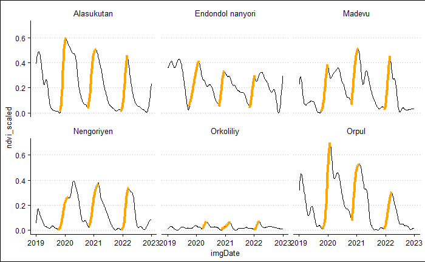

```r
tpw_growth_fitted %>%
  filter(plot_id %in% sample_plots) %>%
  ggplot(aes(x = imgDate)) +
  geom_line(aes(y = ndvi_scaled)) +
  geom_line(aes(y = .fitted), colour = "orange", size = 1.5) +
  facet_wrap(~plot_id) +
  theme_clean()
```

```r
# Decay
decay_fitted <- tpw_decay_model %>%
  mutate(values = map(mod, augment)) %>%
  unnest(values) %>%
  arrange(plot_id, hyear)

tpw_decay_fitted <- tpw_fitting %>%
  ungroup() %>%
  arrange(plot_id, hyear) %>%
  left_join(decay_fitted, by = c("plot_id", "hyear", "ndvi_scaled" = "ts"))

head(tpw_decay_fitted)
```

| plot_id | imgDate | blue | green | red | ir | ndvi | msavi | lc | precipitation | ndvi_int | ndvi_filtered | dist | max_dist | weight | ndvi_new | hyear | growth_start | growth_end | decay_start | decay_end | ndvi_scaled | growth_leg | decay_leg | mod | date_scaled | .fitted | .resid |
| --- | --- | --- | --- | --- | --- | --- | --- | --- | --- | --- | --- | --- | --- | --- | --- | --- | --- | --- | --- | --- | --- | --- | --- | --- | --- | --- | --- |
| ABB | 2019-01-04 | 0.1054 | 0.1380 | 0.1338 | 0.3194 | 0.4136722 | 0.2757264 | 30 | 0.00000 | 0.4136722 | 0.4700788 | 0.056406584 | 0.1576779 | 0.6422669 | 0.4798001 | 2019 | 2019-05-09 | 2019-07-18 | 2019-01-19 | 2019-05-09 | 0.3578997 | FALSE | FALSE |  | NA | NA | NA |
| ABB | 2019-01-09 | NA | NA | NA | NA | NA | NA | 30 | 0.00000 | 0.4575423 | 0.4673566 | 0.009814265 | 0.1576779 | 0.9377575 | 0.4968413 | 2019 | 2019-05-09 | 2019-07-18 | 2019-01-19 | 2019-05-09 | 0.3749409 | FALSE | FALSE |  | NA | NA | NA |
| ABB | 2019-01-14 | 0.1080 | 0.1324 | 0.1542 | 0.2724 | NA | 0.1732770 | 30 | 0.00000 | 0.5014124 | 0.4617302 | -0.039682203 | 0.1576779 | 1.0000000 | 0.5020324 | 2019 | 2019-05-09 | 2019-07-18 | 2019-01-19 | 2019-05-09 | 0.3801320 | FALSE | FALSE |  | NA | NA | NA |
| ABB | 2019-01-19 | 0.0634 | 0.1050 | 0.0841 | 0.2846 | 0.5452825 | 0.3231104 | 30 | 120.32776 | 0.5452825 | 0.4534564 | -0.091826129 | 0.1576779 | 1.0000000 | 0.4978838 | 2019 | 2019-05-09 | 2019-07-18 | 2019-01-19 | 2019-05-09 | 0.3759834 | FALSE | TRUE |  | NA | NA | NA |
| ABB | 2019-01-24 | 0.0920 | 0.1268 | 0.1176 | 0.3160 | 0.4644809 | 0.3048539 | 30 | 23.28053 | 0.4644809 | 0.4427918 | -0.021689092 | 0.1576779 | 1.0000000 | 0.4866409 | 2019 | 2019-05-09 | 2019-07-18 | 2019-01-19 | 2019-05-09 | 0.3647405 | FALSE | TRUE |  | NA | NA | NA |
| ABB | 2019-01-29 | 0.0936 | 0.1308 | 0.1246 | 0.3400 | 0.4654655 | 0.3178724 | 30 | 14.46670 | 0.4654655 | 0.4299931 | -0.035472357 | 0.1576779 | 1.0000000 | 0.4702843 | 2019 | 2019-05-09 | 2019-07-18 | 2019-01-19 | 2019-05-09 | 0.3483839 | FALSE | TRUE |  | NA | NA | NA |

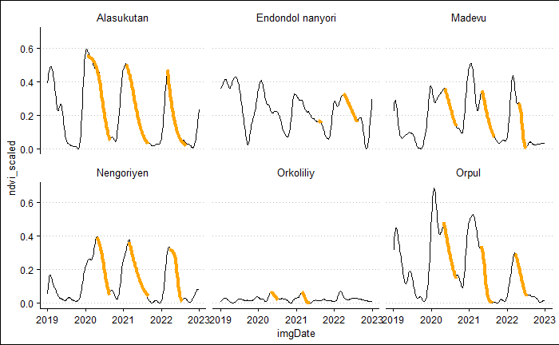

```r
tpw_decay_fitted %>%
  filter(plot_id %in% sample_plots) %>%
  ggplot(aes(x = imgDate)) +
  geom_line(aes(y = ndvi_scaled)) +
  geom_line(aes(y = .fitted), colour = "orange", size = 1.5) +
  facet_wrap(~plot_id) +
  theme_clean()
```

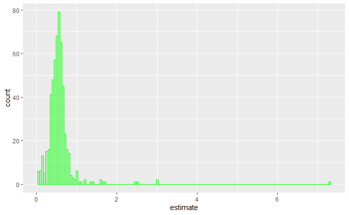

```r
growth_params %>%
  filter(term == "K") %>%
  ggplot(aes(x = estimate)) +
  geom_histogram(fill = "light green", colour = "green", alpha = 0.6,
                 binwidth = 0.05)
```

```r
NA
NA
```